# Applied Psychophysics

Mats E. Nilsson

# **Notes Seminar 1** (2017-10-03)

## What is Psychophysics?

The scientific study of the **relation** between stimulus and sensation [Gescheider]

The analysis of perceptual processes by studying the effect on a subject’s experience or behaviour of **systematically varying** the properties of a stimulus along one or more physical dimensionsâ [Bruce et al., 1996]

Psychophysics also refers to a **general class of methods** that can be applied to study a perceptual system. Modern applications rely heavily on threshold measurement, ideal observer analysis, and signal detection theory. [Wickipedia]

## Psychophysic, data and evidence

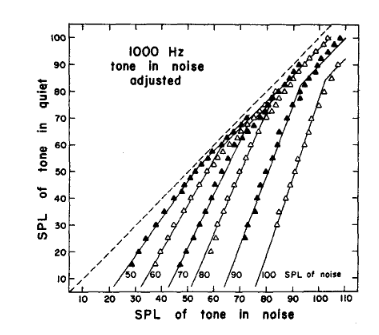

Stevens & Guirao, 1967

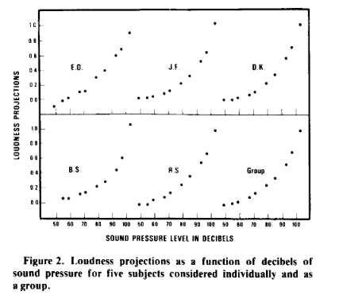

Schneider, 1980

## A brief history of psychophysics

… and what this course is about and not about.

[figure not shown]

**Gustav Fechner** (1801-1887):

- Fechner Day: October 22, 1850. Fechner awoke with a sudden insight into how to study the mind through the relation between stimuli and the perceptions and sensations they affect (see anydayguide.com/calendar/2636)
- Elements of Psychophysics, 1860

#### Three traditions of psychophysics

- **Clasical Psychophysics**
- **Signal Detection Theory**
- **Scaling** (not covered)

#### What about **Reaction Time**?

## About this course

### Examination

To pass the course, you need to deliver the following:

1. Lab report common experiment (more below)
2. Lab report individual experiment (more below)
3. R-function simulating SDT

#### R-function

Function that takes four arguments:

- dprime,
- criterion (c),
- standard deviation of noise distribution (N), and
- standard deviation of signal+noise distribution (S+N).

Output: Figures of (a) N and S+N distributions and (b) ROC.

**Example output:**

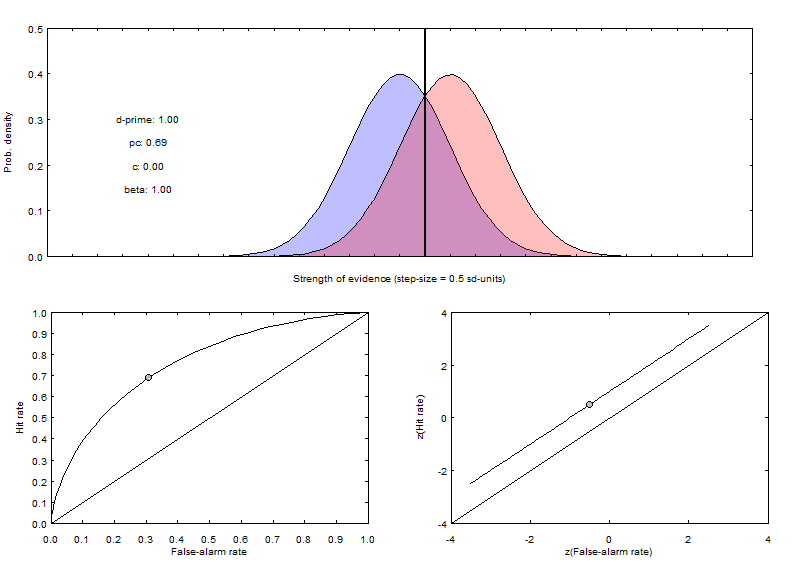

**Deadlines**

- Initial submissions no later than 1 month after the final seminar
- Revisions no later than 2 months after the final seminar

### Seminars

Each seminar is divided in three parts:

1. Theory
2. Python coding: common experiment
3. Python coding: individual experiments

#### (1) Theory

- Seminar 1. (today). Introduction to psychophysics
- Seminar 2. Key concepts and distinctions (K&N, Chs. 2-3)
- Seminar 3. Psychometric functions (K&N, Ch. 4; K&M, Chs. 4-5)
- Seminar 4. Adaptive methods (K&N, Ch. 5)
- Seminar 5. SDT, fundamentals (K&N, Ch. 6)
- Seminar 6. SDT, simulation (K&M, Ch. 3)

#### (2) Python coding: common experiment on detection of a repeated noise

When a nosie is added to itself with a small time-separation, the combined noise gets a pitch-like sound character (called “repetition pitch”). The strength of the pitch perception depends on several factors, including length of time-separation and sound pressure level (SPL) of the added noise relative to the first noise. In this experiment, we will determine thresholds of SPL of second noise re first noise separately for five time-separations: 0.5, 1, 2, 4 and 8 ms.

Examples of how to generate stimuli is found in the script repetition_pitch.py at github.com/stamnosslin/mn

#### (3) Python coding: individual experiments

**Present your idea for individual experiment on Seminar 2**: Problem, Stimulus generation, Psychophysical method, Data presentation (key Figure or Table).

### Python or R or both?

Google **Python or R?** and you’ll find a lot of interesting discussions. The typical answer seem to be **Both!**

Below link for recent data on the growth of Python

https://stackoverflow.blog/2017/09/06/incredible-growth-python/